# OptimizedRNN1New

*Code and documentation written by group members*

Model name : RNN1

Type of Classification: Binary classification - Stress and Non Stress

**1. Loading the EEG data samples and its labels**

- The dataset folder consists of an Excel file called "scales.xls" which consists of the subjects' stress level rating from 1-10. We consider this as the labels for the corresponding EEG samples from the dataset.
- For example, if we load an EEG sample of subject 10 from the dataset, his/her stress rating for that mental task is used as the EEG sample's label.
- The EEG samples file names are formatted in the following manner: MentalTaskType_sub_no_trial_no.mat - for example: Relax_sub_2_trial2.mat
  - Mental Task Type : either Arithmetic, Stroop, Mirror_Image or Relax
  - sub_no : Subject Number
  - trial_no : Trial Number

  The functions in the following code block and their functionalities:
  - extract_number(file_name_snippet) : extracts the trial number from the given filename snippet
  - extract_label_address(file_name) : divides the file name into 4 sections and extracts the task type, subject number and trial number. The function uses this information to calculate and return the label address on the Excel sheet. The Relax EEG samples do not have ratings on the Excel sheet, they automatically return stress rating 0.
  - diff_label(original_stress_label) : the label from the Excel sheet ranges from 1 to 10. However, we want to group the labels to either 0 or 1, as we are performing binary classification. So the EEG samples with label from 1 to 10 were mapped to the stress label 1 (to signify stress) and the EEG samples which were from files labelled as "Relax" with stress rating 0 were mapped to stress label 0 (to signify non-stress)
  - read_data(file_array) : takes in a string array of filepaths of all the EEG sample files and extracts the EEG coordinates from each filepath. Stores each file's EEG coordinates in an array and gets its corresponding label using extract_label_address(). This function returns two arrays: an array storing arrays of each files' EEG coordinates called all_samples and an array called all_labels, which stores each file's corresponding label to feed into the model.

```python
import numpy as np
from sklearn.model_selection import train_test_split
from sklearn.svm import LinearSVC
from sklearn.preprocessing import StandardScaler
from glob import glob
import matplotlib.pyplot as plt
import scipy.io
import os
import matplotlib.pyplot as plt
import pandas as pd

# for labels in later stages
def extract_number(string):
    for char in string:
        if char.isdigit():
            return int(char)
    return None

# takes filepath as param, returns indices for address of stress level label in xls file
def extract_label_address(string):
    arr=string.split(os.path.sep)[-1].split("_") # ['Arithmetic', 'sub', '10', 'trial1.mat']
    base_num=0
    if ("Arithmetic" in arr[0]):
        base_num=1
    elif ("Mirror" in arr[0]):
        base_num=2
    elif ("Stroop" in arr[0]):
        base_num=3
    else:
        return 0,0
    trial_no=extract_number(arr[-1])
    if trial_no==2:
        base_num+=3
    elif trial_no==3:
        base_num+=6
    return int(arr[-2]),base_num # returns address of cell in excel file

# stress levels are from 1 - 10, reduced the levels to 0,1 labels
def diff_label(stress_label):
    if stress_label==0:
        return 0
    else:
        return 1
    return stress_label

# total 480 files, 3 trials for each of the 40 participants in each of the 4 experiments
all_file_paths=sorted(glob("C:\\Users\\Manoharan\\Desktop\\SE Group Project Notes\\Model Prototypes\\filtered_data/*.mat"))

# reading excel file's stress level labels - arr stores the full excel file's contents
stress_levels_arr = pd.read_excel('C:\\Users\\Manoharan\\Desktop\\SE Group Project Notes\\Model Prototypes\\Dataset_Information\\scales.xls').to_numpy()

# reads the data and returns the samples array and its label array
def read_data(file_paths):
    data = scipy.io.loadmat(file_paths[0])
    eeg_data = data["Clean_data"]
    all_epochs=[eeg_data]
    addr1,addr2=extract_label_address(file_paths[0])
    all_labels=[diff_label(stress_levels_arr[addr1][addr2])]
    for i in range(1,len(file_paths)):
        data = scipy.io.loadmat(file_paths[i])
        eeg_data = data["Clean_data"]
        all_epochs=np.append(all_epochs,[eeg_data],axis=0)
        addr1,addr2=extract_label_address(file_paths[i])
        if (addr1!=0 and addr2!=0): # if addr1, addr2 == 0,0: we are labelling a Relaxation epoch
            all_labels=np.append(all_labels,[diff_label(stress_levels_arr[addr1][addr2])],axis=0)
        else:
            all_labels=np.append(all_labels,[diff_label(0)],axis=0)
    return all_epochs,all_labels
```

```python
# total 480 samples in SAM-40 dataset
# each epoch is of shape (32,3200), total 120 epochs per experiment
# test if labels correct
addr1,addr2=extract_label_address(all_file_paths[304])
print(all_file_paths[304])
print(stress_levels_arr[addr1][addr2])
```

```
C:\Users\Manoharan\Desktop\SE Group Project Notes\Model Prototypes\filtered_data\Relax_sub_2_trial2.mat
0
```

```python
all_samples,all_labels=read_data(all_file_paths) # shape should be (480,32,3200) and (480,) respectively
```

```python
all_samples2=all_samples
```

```python
# extract optimal channels for detecting stress levels
#optimal_Channel_indices = [2,31]
#new_samples = all_samples2[:, optimal_Channel_indices, :]
new_samples = all_samples
print(new_samples.shape)
```

```
(480, 32, 3200)
```

# Dataset Handling

# Feature Extraction from SAM-40 Dataset

- The function get_freq_bands() takes an EEG channel's values and returns the power spectrum within specified frequency bands.
- main_array Structure: main_array is to be fed into the model, it is of shape (480, 2, 940), where:
  - The first dimension (480) represents the samples.
  - The second dimension (2) represents the two channels, Fp1 and Fp2.
  - The third dimension (940) represents the features extracted from each channel.
- For each sample (loop over 480 samples),the EEG channels Fp1 and Fp2 are extracted (already proven before that these are optimal channels with accuracy over 90%).
- For each channel, the power spectrum within the defined frequency bands is computed using Fast Fourier Transform. This power spectra of delta, theta, alpha, beta, and gamma bands are placed into separate arrays for each channel.
- Since gamma features reached over 800, it was trimmed. The arrays for delta, gamma, theta, alpha and beta were concatenated to form one large array of all the five band's features. This array is of size 940. Finally, the large array containing all the features for each channel is stored in the main_array.

```python
# extracting frequency bands from each channel

def get_freq_bands(eeg_signal):
    # define sampling rate
    sampling_rate = 128  # for the Emotiv headset from SAM-40 headset
    frequency_bands = {
        'delta': (0.5, 4),
        'theta': (4, 8),
        'alpha': (8, 13),
        'beta': (13, 30),
        'gamma': (30, 100)
    }

    # perform FFT
    fft_result = np.fft.fft(eeg_signal)

    # calculating frequency values
    freqs = np.fft.fftfreq(len(eeg_signal), 1/sampling_rate)

    # initialize arrays to store power in each band
    band_powers = {band: np.zeros_like(eeg_signal, dtype=float) for band in frequency_bands}

    # iterate over the frequency bands and calculate each power
    for band, (low, high) in frequency_bands.items():
        band_mask = np.logical_and(freqs >= low, freqs <= high)
        band_indices = np.where(band_mask)
        band_powers[band] = np.abs(fft_result)[band_indices]
    return band_powers

# all_samples (480,2,940) Fp1 and Fp2's features size
main_array=np.zeros((480, 2, 940))
optimal_channel_nums = [2,31] #2,4,24,25,26,29,30,31 - 0,2,30,31 - i for i in range(32)
num = -1
for i in range(480):
    num=-1
    for j in optimal_channel_nums:

        eeg_channel = new_samples[i][j]

        band_powers_dict=get_freq_bands(eeg_channel)

        # trim gamma features for fitting
        band_powers_gamma_trimmed = band_powers_dict['gamma'][:-651]

        # concatenate band powers for channel Fp1
        array1 = np.concatenate((band_powers_dict['delta'],
                                  band_powers_dict['theta'],
                                  band_powers_dict['alpha'],
                                  band_powers_dict['beta'],
                                 band_powers_gamma_trimmed), axis=0)
        num+=1
        main_array[i, num] = array1
```

# Architecture of the RNN Model

# Compilation

The model is compiled using the Adam optimizer and binary crossentropy loss function. Accuracy is used as the evaluation metric.

# Training the Model

The model is trained for 20 epochs with a batch size of 32. The training progress is monitored, and validation data is used to evaluate the model's performance during training.

```
Test Accuracy: 95.37%
```

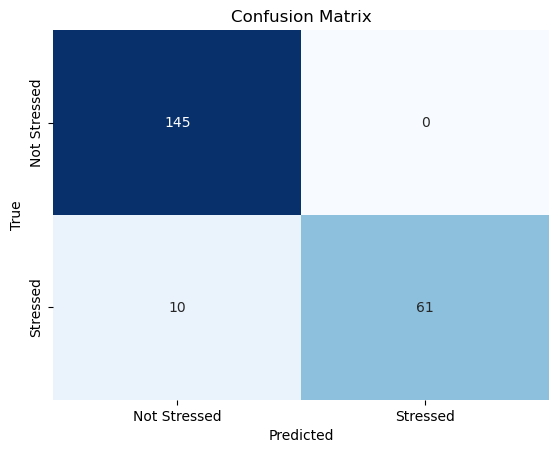

```python
import tensorflow as tf
from tensorflow.keras import layers, models
from sklearn.model_selection import train_test_split
from sklearn.metrics import confusion_matrix
import numpy as np
import seaborn as sns
import matplotlib.pyplot as plt
import h5py


# identify indices of non-stress class
non_stress_indices = np.where(all_labels == 0)[0]

oversampling_factor = 5

# replicate non-stress samples (due to class imbalance)
replicated_samples = np.repeat(main_array[non_stress_indices], oversampling_factor, axis=0)
replicated_labels = np.repeat(all_labels[non_stress_indices], oversampling_factor)

# combine with the original data
oversampled_samples = np.vstack([main_array, replicated_samples]) # 960,2,3200
oversampled_labels = np.concatenate([all_labels, replicated_labels])

# split oversampled data into training and testing sets
X_train, X_test, y_train, y_test = train_test_split(oversampled_samples, oversampled_labels, test_size=0.2, random_state=42)

model = models.Sequential()

# add SimpleRNN layer with return_sequences=True for multiple time steps
model.add(layers.SimpleRNN(128, activation='relu', kernel_regularizer=tf.keras.regularizers.l2(0.01), input_shape=(2, 940), return_sequences=True))

model.add(layers.SimpleRNN(64, activation='relu', kernel_regularizer=tf.keras.regularizers.l2(0.01)))

# flatten output before passing it to Dense layer
model.add(layers.Flatten())

model.add(layers.Dense(64, activation='relu'))

# final output layer
model.add(layers.Dense(1, activation='sigmoid'))

# compile model
model.compile(optimizer=tf.keras.optimizers.Adam(learning_rate=0.001), loss='binary_crossentropy', metrics=['accuracy'])

# model training
history = model.fit(X_train, y_train, epochs=20, batch_size=32, validation_data=(X_test, y_test))

# evaluate the model
loss, accuracy = model.evaluate(X_test, y_test)
print(f'Test Accuracy: {accuracy * 100:.2f}%')

# predict on test set
y_pred = model.predict(X_test)
y_pred_binary = np.round(y_pred)

conf_matrix = confusion_matrix(y_test, y_pred_binary)

sns.heatmap(conf_matrix, annot=True, fmt='g', cmap='Blues', cbar=False,
            xticklabels=['Not Stressed', 'Stressed'], yticklabels=['Not Stressed', 'Stressed'])
plt.xlabel('Predicted')
plt.ylabel('True')
plt.title('Confusion Matrix')
plt.show()
```

# Performance Metrics and Test Accuracy

Report generated below provides a summary of various classification metrics such as precision, recall, F1-score, and support for each class. This reports the evaluation of testing using 20% of the data from the dataset.

```python
from sklearn.metrics import classification_report
print(f'Test Accuracy:',accuracy * 100)
# output confusion matrix
print("Confusion Matrix:")
conf_matrix = confusion_matrix(y_test, y_pred_binary)
print(conf_matrix)

# generate and print the classification report
print("\nClassification Report:")
print(classification_report(y_test, y_pred_binary))
```

```
Test Accuracy: 95.37037014961243
Confusion Matrix:
[[145   0]
 [ 10  61]]

Classification Report:
              precision    recall  f1-score   support

           0       0.94      1.00      0.97       145
           1       1.00      0.86      0.92        71

    accuracy                           0.95       216
   macro avg       0.97      0.93      0.95       216
weighted avg       0.96      0.95      0.95       216
```

# File upload and processing (.mat file extension)

- the following code block performs uploading of an EEG sample in .mat format (from the SAM-40 dataset) and shows the model's prediction and the actual label.

```python
# simple testing for model - checking if it predicts correctly for a random EEG data sample from dataset

import numpy as np
from scipy.io import loadmat

# load EEG data from .mat file - example

test_index=300
optimal_Channel_indices = [2,31]
new_user_input = loadmat(all_file_paths[test_index])   # loads eeg data at index 301 for prediction
eeg_data = new_user_input["Clean_data"]

# flatten input data along channel axis
selected_data = eeg_data[optimal_Channel_indices, :]
eeg_channel_Fp1 = selected_data[0]
eeg_channel_Fp2 = selected_data[1]

band_powers1_dict=get_freq_bands(eeg_channel_Fp1)
band_powers2_dict=get_freq_bands(eeg_channel_Fp2)

# trim gamma features for fitting
band_powers1_gamma_trimmed = band_powers1_dict['gamma'][:-651]
band_powers2_gamma_trimmed = band_powers2_dict['gamma'][:-651]

# concatenate band powers for channel Fp1
fp1_band_powers = np.concatenate((band_powers1_dict['delta'],
                         band_powers1_dict['theta'],
                         band_powers1_dict['alpha'],
                         band_powers1_dict['beta'],
                         band_powers1_gamma_trimmed), axis=0)

# concatenate band powers for channel Fp2
fp2_band_powers = np.concatenate((band_powers2_dict['delta'],
                         band_powers2_dict['theta'],
                         band_powers2_dict['alpha'],
                         band_powers2_dict['beta'],
                         band_powers2_gamma_trimmed), axis=0)

selected_data=np.zeros((2, len(fp1_band_powers)))

selected_data[0]=fp1_band_powers
selected_data[1]=fp2_band_powers
input_for_model1=selected_data
input_for_model1 = np.expand_dims(input_for_model1, axis=0)

prediction = model.predict(input_for_model1)

# Round the prediction to get binary output (if needed)
binary_prediction = np.round(prediction)

# Print the prediction
print("Actual Label:", all_labels[test_index])
print("Binary prediction:", binary_prediction[0][0])
```

```
Actual Label: 0
Binary prediction: 0.0
```

# File upload and processing (.csv file extension)

- the following code block performs uploading of an EEG sample in .csv format (the samples we received from the Muse headset) and shows the model's prediction. Since we were performing the Stroop test as the sample was taken, we expected that the model should predict that the sample should be classified as stressed. The prediction was as expected, the predicted 1.0 means stress.

```python
import pandas as pd
import numpy as np

# Read the CSV file
df = pd.read_csv("C:\\Users\\Manoharan\\Desktop\\Final Models\\classical_rick.csv",header=0)

# filter out empty rows - due to eye blinks
filtered_df = df.dropna(subset=[df.columns[1]])

array_2d = filtered_df.values

AF7_band_powers=filtered_df.iloc[:, [2,6,10,14,18]]
AF8_band_powers=filtered_df.iloc[:, [3,7,11,15,19]]

AF7_band_powers=AF7_band_powers.values.flatten()
AF8_band_powers=AF8_band_powers.values.flatten()

input_for_model=np.zeros((2, len(AF7_band_powers)))
input_for_model[0]=AF7_band_powers
input_for_model[1]=AF8_band_powers

input_for_model = np.expand_dims(input_for_model, axis=0)

prediction = model.predict(input_for_model)

# Round the prediction to get binary output (if needed)
binary_prediction = np.round(prediction)

# Print the prediction
print("Binary prediction:", binary_prediction[0][0])
```

```
Binary prediction: 1.0
```

# Saving the Trained Model

This action ensures that the trained model can be easily retrieved and reused for future predictions or analysis without the need to retrain it. The .h5 version will be used when the model is required to classify a user's EEG sample for the website.

```python
import h5py
# Save the trained model to an HDF5 file
model.save("C:/Users/Manoharan/Desktop/RNN1.h5")
```